# DA5020.A2.Yicheng.Zhang

YICHENG ZHANG

2022-09-13

```r
library(ggplot2)
library(scales)
library(dplyr)
```

## Question 2

```r
tableQ2 <- msleep %>%
    group_by(vore) %>%
    summarise(Count = n()) %>%
    mutate( vore = factor(vore),
            Ratio = Count / sum(Count),
            label = percent(Ratio))
tableQ2
```

```
## # A tibble: 5 × 4
##   vore    Count  Ratio label
##   <fct>   <int>  <dbl> <chr>
## 1 carni      19 0.229  22.9%
## 2 herbi      32 0.386  38.6%
## 3 insecti     5 0.0602 6.0%
## 4 omni       20 0.241  24.1%
## 5 <NA>        7 0.0843 8.4%
```

Here is the output of the percentage of each different vore categories in a table view. NA value included. Then we visualizing it:

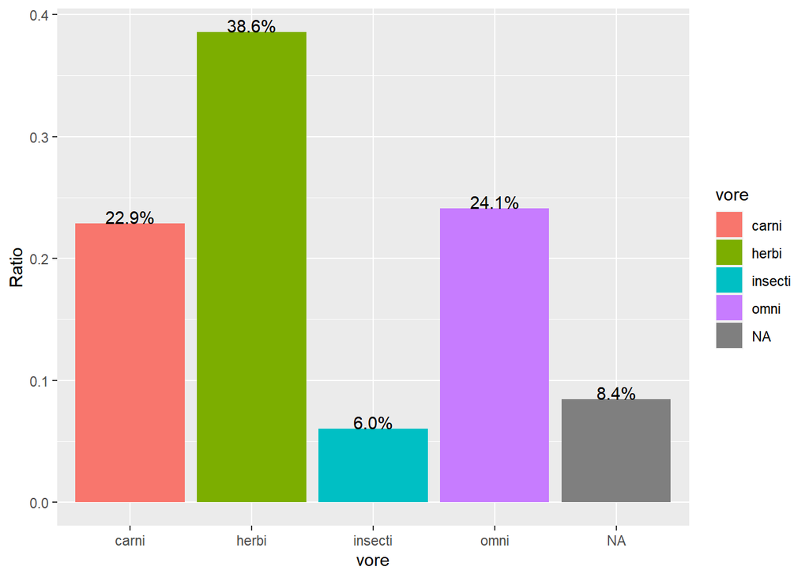

```r
visual_result <- ggplot(tableQ2, aes(x=vore,y=Ratio,label=label,fill=vore)) +
    geom_bar(stat='identity') +
    geom_text(vjust=0)
visual_result
```

## Question 3

```r
omni_only<-msleep %>% filter(vore == "omni")
mean(omni_only$sleep_total)
```

```
## [1] 10.925
```

The means value of the total sleep times (in hours) is 10.925 in just omnivores species.

## Question 4

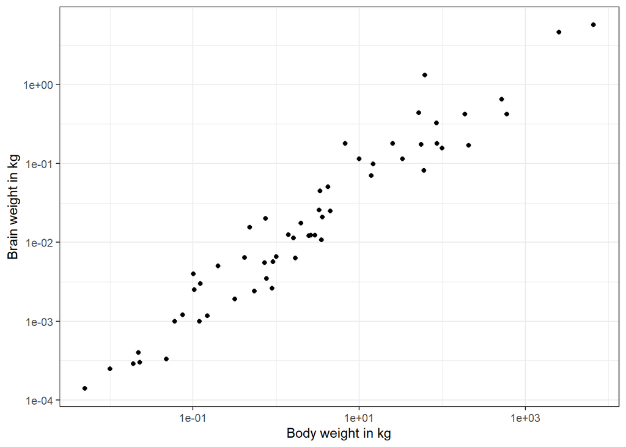

```r
ggplot(data = msleep, aes(x = bodywt, y = brainwt)) +
  geom_point() +
  scale_x_log10() +
  scale_y_log10() +
  theme_bw() +
  labs(x = "Body weight in kg",
       y = "Brain weight in kg")
```

From the output of this question, we can see that there is a positive relationship between body weight and brain weight after we perform log transformation to both of them. And brain weight is also propotional to the body weight, the increase of the body will also cause the increase of the brain weight. Also, from the pattern of the plot, there is a strong linear relationship between these two covariates.

## Question 5

```r
# Here is the result of the Pearson coefficient of correlation

c<-cor(msleep$bodywt,msleep$brainwt,use = "complete.obs")
c
```

```
## [1] 0.9337822
```

Since the corrilation coefficient is 0.9337822, we can say that the result of the correlation proved our assumption in Q4. A correlation is a value between -1 to 1 and the more closer to the border the magnitude of it will indicate the strength (a clear linear pattern). The correlation coefficient close to 1 indicate the near perfect positive correlation (the plot we got from question 4). And the sign of the correlation coefficient will tell us the direction, here we have a positive result so the body weight and brain weight should have a positive correlation. All of these features are showed on the plot from Question 4 so we say the results support our original assumptions from question 4.

## Question 6

```r
# In this question, all the value beyond mean(sleep_total)±1.5 should be consider as outlier.
# We first find out all the outliers that have value larger than the mean(sleep_total)+1.5

outlier1<-msleep %>% filter(sleep_total>mean(sleep_total)+1.5*sd(sleep_total)|sleep_total < mean(sleep_total) - 1.5*sd(sleep_total))%>%select(name, sleep_total)

# print the result

print.data.frame(outlier1)
```

```
##                      name sleep_total
## 1                Roe deer         3.0
## 2    Long-nosed armadillo        17.4
## 3  North American Opossum        18.0
## 4           Big brown bat        19.7
## 5                   Horse         2.9
## 6                  Donkey         3.1
## 7                 Giraffe         1.9
## 8             Pilot whale         2.7
## 9        African elephant         3.3
## 10   Thick-tailed opposum        19.4
## 11       Little brown bat        19.9
## 12           Caspian seal         3.5
## 13        Giant armadillo        18.1
```

In this question, we first set the boundary to distinguish outliers and in this case we want to consider all the mammals that not in the range `mean(sleep_total)±1.5*sd(sleep_total)` as outliers. And we find out them separately with the help of the `|`, first find those mammals who have sleep hours larger than `mean(sleep_total)+1.5*sd(sleep_total)` and then find those who have sleeping hours less than `mean(sleep_total)-1.5*sd(sleep_total)`. Therefore we can get result fulfill both boundaries, from the output of them, 13 mammals that are outliers are listed above and their total sleep hours as well.